# SAMPLE SUPERSTORE

DATA SCIENCE AND BUSINESS ANALYTICS INTERN AT THE SPARKS FOUNDATION

EXPLORATORY DATA ANALYSIS ON SAMPLE SUPERSTORE

```python
#importing necessary libraries
import pandas as pd
import numpy as np
import matplotlib.pyplot as plt
%matplotlib inline
import seaborn as sns
```

%matplotlib inline is a magic command and sets Matplotlib to display plots directly within the Jupyter Notebook interface rather than opening a separate window or external viewer for the plots.

```python
df=pd.read_csv('Documents/SampleSuperstore.csv')
df
```

|  | Ship Mode | Segment | Country | City | State | Region | Category | Sub-Category | Sales | Quantity | Discount | Profit |
| --- | --- | --- | --- | --- | --- | --- | --- | --- | --- | --- | --- | --- |
| 0 | Second Class | Consumer | United States | Henderson | Kentucky | South | Furniture | Bookcases | 261.9600 | 2 | 0.00 | 41.9136 |
| 1 | Second Class | Consumer | United States | Henderson | Kentucky | South | Furniture | Chairs | 731.9400 | 3 | 0.00 | 219.5820 |
| 2 | Second Class | Corporate | United States | Los Angeles | California | West | Office Supplies | Labels | 14.6200 | 2 | 0.00 | 6.8714 |
| 3 | Standard Class | Consumer | United States | Fort Lauderdale | Florida | South | Furniture | Tables | 957.5775 | 5 | 0.45 | -383.0310 |
| 4 | Standard Class | Consumer | United States | Fort Lauderdale | Florida | South | Office Supplies | Storage | 22.3680 | 2 | 0.20 | 2.5164 |
| ... | ... | ... | ... | ... | ... | ... | ... | ... | ... | ... | ... | ... |
| 9972 | Second Class | Consumer | United States | Miami | Florida | South | Furniture | Furnishings | 25.2480 | 3 | 0.20 | 4.1028 |
| 9973 | Standard Class | Consumer | United States | Costa Mesa | California | West | Furniture | Furnishings | 91.9600 | 2 | 0.00 | 15.6332 |
| 9974 | Standard Class | Consumer | United States | Costa Mesa | California | West | Technology | Phones | 258.5760 | 2 | 0.20 | 19.3932 |
| 9975 | Standard Class | Consumer | United States | Costa Mesa | California | West | Office Supplies | Paper | 29.6000 | 4 | 0.00 | 13.3200 |
| 9976 | Second Class | Consumer | United States | Westminster | California | West | Office Supplies | Appliances | 243.1600 | 2 | 0.00 | 72.9480 |

9977 rows × 12 columns

```python
df.shape
```

```
(9977, 12)
```

df.shape gives the total number of rows and columns present in the dataset.

```python
df.info()
```

```
<class 'pandas.core.frame.DataFrame'>
RangeIndex: 9977 entries, 0 to 9976
Data columns (total 12 columns):
 #   Column        Non-Null Count  Dtype
---  ------        --------------  -----
 0   Ship Mode     9977 non-null   object
 1   Segment       9977 non-null   object
 2   Country       9977 non-null   object
 3   City          9977 non-null   object
 4   State         9977 non-null   object
 5   Region        9977 non-null   object
 6   Category      9977 non-null   object
 7   Sub-Category  9977 non-null   object
 8   Sales         9977 non-null   float64
 9   Quantity      9977 non-null   int64
 10  Discount      9977 non-null   float64
 11  Profit        9977 non-null   float64
dtypes: float64(3), int64(1), object(8)
memory usage: 935.5+ KB
```

```python
df.head()
```

|  | Ship Mode | Segment | Country | City | State | Region | Category | Sub-Category | Sales | Quantity | Discount | Profit |
| --- | --- | --- | --- | --- | --- | --- | --- | --- | --- | --- | --- | --- |
| 0 | Second Class | Consumer | United States | Henderson | Kentucky | South | Furniture | Bookcases | 261.9600 | 2 | 0.00 | 41.9136 |
| 1 | Second Class | Consumer | United States | Henderson | Kentucky | South | Furniture | Chairs | 731.9400 | 3 | 0.00 | 219.5820 |
| 2 | Second Class | Corporate | United States | Los Angeles | California | West | Office Supplies | Labels | 14.6200 | 2 | 0.00 | 6.8714 |
| 3 | Standard Class | Consumer | United States | Fort Lauderdale | Florida | South | Furniture | Tables | 957.5775 | 5 | 0.45 | -383.0310 |
| 4 | Standard Class | Consumer | United States | Fort Lauderdale | Florida | South | Office Supplies | Storage | 22.3680 | 2 | 0.20 | 2.5164 |

df.head()returns the first 5 rows in the data.We can specify the number of rows

```python
df.head(15)
```

|  | Ship Mode | Segment | Country | City | State | Region | Category | Sub-Category | Sales | Quantity | Discount | Profit |
| --- | --- | --- | --- | --- | --- | --- | --- | --- | --- | --- | --- | --- |
| 0 | Second Class | Consumer | United States | Henderson | Kentucky | South | Furniture | Bookcases | 261.9600 | 2 | 0.00 | 41.9136 |
| 1 | Second Class | Consumer | United States | Henderson | Kentucky | South | Furniture | Chairs | 731.9400 | 3 | 0.00 | 219.5820 |
| 2 | Second Class | Corporate | United States | Los Angeles | California | West | Office Supplies | Labels | 14.6200 | 2 | 0.00 | 6.8714 |
| 3 | Standard Class | Consumer | United States | Fort Lauderdale | Florida | South | Furniture | Tables | 957.5775 | 5 | 0.45 | -383.0310 |
| 4 | Standard Class | Consumer | United States | Fort Lauderdale | Florida | South | Office Supplies | Storage | 22.3680 | 2 | 0.20 | 2.5164 |
| 5 | Standard Class | Consumer | United States | Los Angeles | California | West | Furniture | Furnishings | 48.8600 | 7 | 0.00 | 14.1694 |
| 6 | Standard Class | Consumer | United States | Los Angeles | California | West | Office Supplies | Art | 7.2800 | 4 | 0.00 | 1.9656 |
| 7 | Standard Class | Consumer | United States | Los Angeles | California | West | Technology | Phones | 907.1520 | 6 | 0.20 | 90.7152 |
| 8 | Standard Class | Consumer | United States | Los Angeles | California | West | Office Supplies | Binders | 18.5040 | 3 | 0.20 | 5.7825 |
| 9 | Standard Class | Consumer | United States | Los Angeles | California | West | Office Supplies | Appliances | 114.9000 | 5 | 0.00 | 34.4700 |
| 10 | Standard Class | Consumer | United States | Los Angeles | California | West | Furniture | Tables | 1706.1840 | 9 | 0.20 | 85.3092 |
| 11 | Standard Class | Consumer | United States | Los Angeles | California | West | Technology | Phones | 911.4240 | 4 | 0.20 | 68.3568 |
| 12 | Standard Class | Consumer | United States | Concord | North Carolina | South | Office Supplies | Paper | 15.5520 | 3 | 0.20 | 5.4432 |
| 13 | Standard Class | Consumer | United States | Seattle | Washington | West | Office Supplies | Binders | 407.9760 | 3 | 0.20 | 132.5922 |
| 14 | Standard Class | Home Office | United States | Fort Worth | Texas | Central | Office Supplies | Appliances | 68.8100 | 5 | 0.80 | -123.8580 |

```python
df.tail()
```

|  | Ship Mode | Segment | Country | City | State | Region | Category | Sub-Category | Sales | Quantity | Discount | Profit |
| --- | --- | --- | --- | --- | --- | --- | --- | --- | --- | --- | --- | --- |
| 9972 | Second Class | Consumer | United States | Miami | Florida | South | Furniture | Furnishings | 25.248 | 3 | 0.2 | 4.1028 |
| 9973 | Standard Class | Consumer | United States | Costa Mesa | California | West | Furniture | Furnishings | 91.960 | 2 | 0.0 | 15.6332 |
| 9974 | Standard Class | Consumer | United States | Costa Mesa | California | West | Technology | Phones | 258.576 | 2 | 0.2 | 19.3932 |
| 9975 | Standard Class | Consumer | United States | Costa Mesa | California | West | Office Supplies | Paper | 29.600 | 4 | 0.0 | 13.3200 |
| 9976 | Second Class | Consumer | United States | Westminster | California | West | Office Supplies | Appliances | 243.160 | 2 | 0.0 | 72.9480 |

This gives the bottom 5 rows

```python
df.duplicated().sum()
```

```
33
```

This gives us the total number of duplicate records in the dataframe

```python
df.shape
```

```
(9977, 12)
```

```python
df.drop_duplicates(inplace=True)
df
```

|  | Ship Mode | Segment | Country | City | State | Region | Category | Sub-Category | Sales | Quantity | Discount | Profit |
| --- | --- | --- | --- | --- | --- | --- | --- | --- | --- | --- | --- | --- |
| 0 | Second Class | Consumer | United States | Henderson | Kentucky | South | Furniture | Bookcases | 261.9600 | 2 | 0.00 | 41.9136 |
| 1 | Second Class | Consumer | United States | Henderson | Kentucky | South | Furniture | Chairs | 731.9400 | 3 | 0.00 | 219.5820 |
| 2 | Second Class | Corporate | United States | Los Angeles | California | West | Office Supplies | Labels | 14.6200 | 2 | 0.00 | 6.8714 |
| 3 | Standard Class | Consumer | United States | Fort Lauderdale | Florida | South | Furniture | Tables | 957.5775 | 5 | 0.45 | -383.0310 |
| 4 | Standard Class | Consumer | United States | Fort Lauderdale | Florida | South | Office Supplies | Storage | 22.3680 | 2 | 0.20 | 2.5164 |
| ... | ... | ... | ... | ... | ... | ... | ... | ... | ... | ... | ... | ... |
| 9972 | Second Class | Consumer | United States | Miami | Florida | South | Furniture | Furnishings | 25.2480 | 3 | 0.20 | 4.1028 |
| 9973 | Standard Class | Consumer | United States | Costa Mesa | California | West | Furniture | Furnishings | 91.9600 | 2 | 0.00 | 15.6332 |
| 9974 | Standard Class | Consumer | United States | Costa Mesa | California | West | Technology | Phones | 258.5760 | 2 | 0.20 | 19.3932 |
| 9975 | Standard Class | Consumer | United States | Costa Mesa | California | West | Office Supplies | Paper | 29.6000 | 4 | 0.00 | 13.3200 |
| 9976 | Second Class | Consumer | United States | Westminster | California | West | Office Supplies | Appliances | 243.1600 | 2 | 0.00 | 72.9480 |

9944 rows × 12 columns

```python
df.shape
```

```
(9944, 12)
```

After removing the duplicate record we have 9944 rows before dropping duplicated we had 9977

```python
df.isnull().sum()
```

```
Ship Mode       0
Segment         0
Country         0
City            0
State           0
Region          0
Category        0
Sub-Category    0
Sales           0
Quantity        0
Discount        0
Profit          0
dtype: int64
```

This will return total null values present in each column

```python
df.describe()
```

|  | Sales | Quantity | Discount | Profit |
| --- | --- | --- | --- | --- |
| count | 9944.000000 | 9944.000000 | 9944.000000 | 9944.000000 |
| mean | 230.752150 | 3.794047 | 0.156440 | 28.770873 |
| std | 624.644765 | 2.228752 | 0.206584 | 234.841370 |
| min | 0.444000 | 1.000000 | 0.000000 | -6599.978000 |
| 25% | 17.340000 | 2.000000 | 0.000000 | 1.724800 |
| 50% | 55.000000 | 3.000000 | 0.200000 | 8.679950 |
| 75% | 210.104000 | 5.000000 | 0.200000 | 29.534700 |
| max | 22638.480000 | 14.000000 | 0.800000 | 8399.976000 |

It provides a summary of statistics for the numerical columns in the DataFrame

```python
df["Region"].unique()
```

```
array(['South', 'West', 'Central', 'East'], dtype=object)
```

This gives the unique value present in region

```python
numerical_columns = df.select_dtypes(include=['int64', 'float64'])
correlation_matrix = numerical_columns.corr()
correlation_matrix
```

|  | Sales | Quantity | Discount | Profit |
| --- | --- | --- | --- | --- |
| Sales | 1.000000 | 0.200469 | -0.028625 | 0.479078 |
| Quantity | 0.200469 | 1.000000 | 0.008307 | 0.066089 |
| Discount | -0.028625 | 0.008307 | 1.000000 | -0.219939 |
| Profit | 0.479078 | 0.066089 | -0.219939 | 1.000000 |

This gives Correlation among numerical variables

DATA VISUALIZATION

Category wise sales

```
[Text(0.5, 1.0, 'Sales by Category')]
```

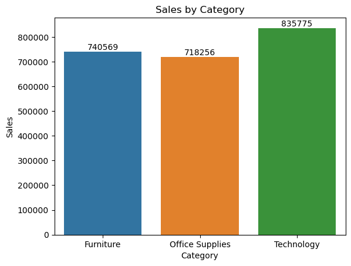

```python
df1=pd.DataFrame(df.groupby(['Category'])['Sales'].sum())
ax=sns.barplot(x=df1.index,y=df1.Sales)
for bars in ax.containers:
    ax.bar_label(bars)
ax.set(title="Sales by Category")
```

Technology was the top-performing category in terms of sales.

Category wise profit

```
[Text(0.5, 1.0, 'Profit by Category')]
```

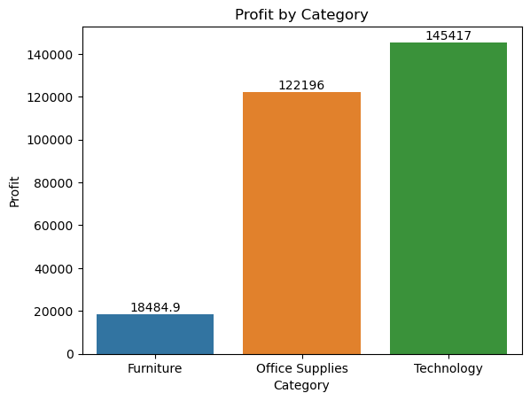

```python
df1=pd.DataFrame(df.groupby(['Category'])['Profit'].sum())
ax=sns.barplot(x=df1.index,y=df1.Profit)
for bars in ax.containers:
    ax.bar_label(bars)
ax.set(title="Profit by Category")
```

Sub-category wise profit & sales

```
[Text(0.5, 1.0, 'Top 10 Sub-Category by Profit ')]
```

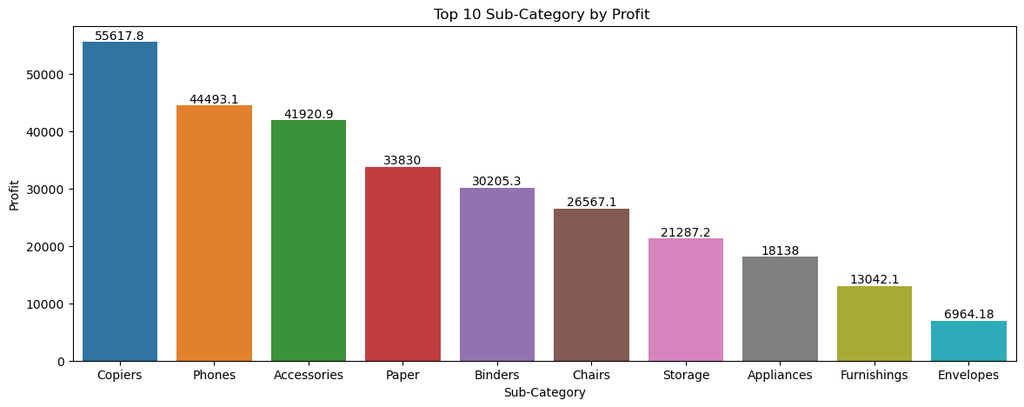

```python
plt.figure(figsize=(14,5))
df1=pd.DataFrame(df.groupby(['Sub-Category'])['Profit'].sum()).sort_values(by='Profit',ascending=False).head(10)
ax=sns.barplot(x=df1.index,y=df1.Profit)
for bars in ax.containers:
    ax.bar_label(bars)
ax.set(title="Top 10 Sub-Category by Profit ")
```

```
[Text(0.5, 1.0, 'Sub-Category by Sales')]
```

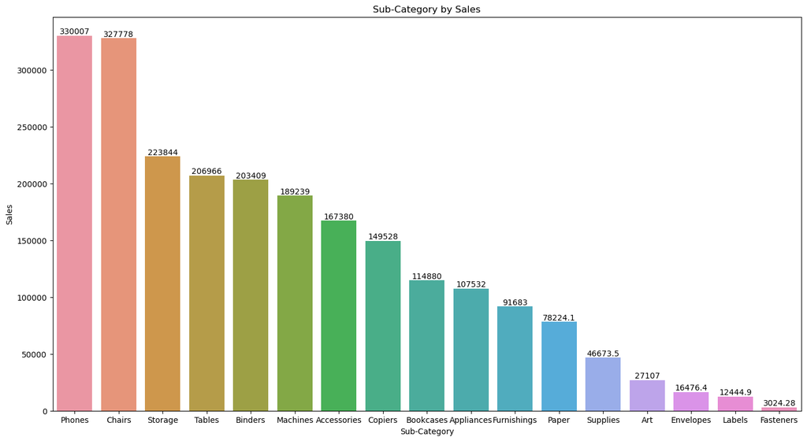

```python
plt.figure(figsize=(17,9))
df1=pd.DataFrame(df.groupby(['Sub-Category'])['Sales'].sum()).sort_values(by='Sales',ascending=False).head(17)
ax=sns.barplot(x=df1.index,y=df1.Sales)
for bars in ax.containers:
    ax.bar_label(bars)
ax.set(title= "Sub-Category by Sales")
```

Preferred ship mode by customers

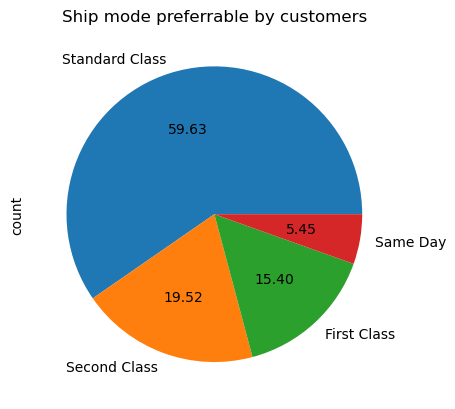

```python
df ['Ship Mode'].value_counts().plot(kind='pie', autopct='%.2f')
plt.title('Ship mode preferrable by customers')
```

Profit Across Different Regions

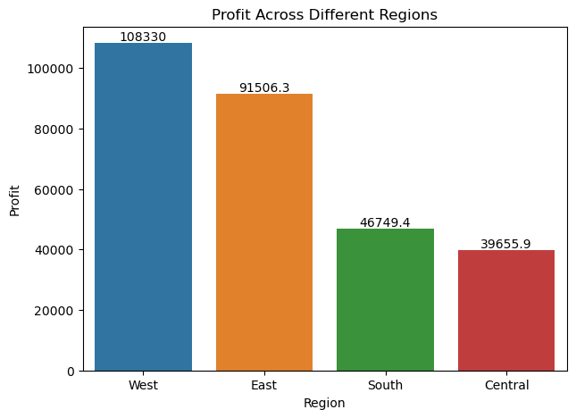

```python
plt.figure(figsize=(7,5))
df1=pd.DataFrame(df.groupby(['Region'])['Profit'].sum()).sort_values(by='Profit',ascending=False).head(10)
ax=sns.barplot(x=df1.index,y=df1.Profit)
for bars in ax.containers:
    ax.bar_label(bars)
plt.title("Profit Across Different Regions")
```

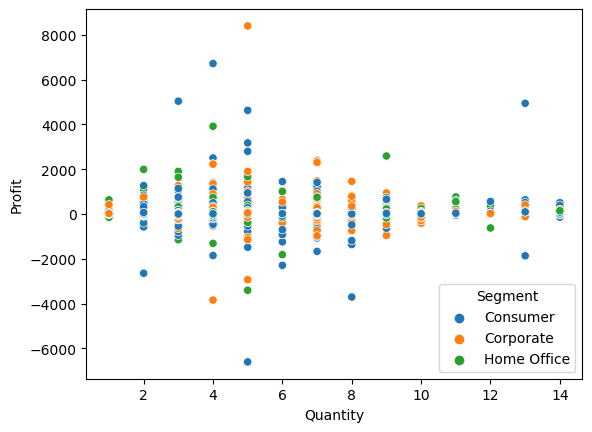

```python
sns.scatterplot(x='Quantity',y='Profit',hue='Segment',data=df)
```

[figure not shown]

```python
plt.figure(figsize=(20,7))
df1=pd.DataFrame(df.groupby(['City'])['Sales'].sum()).sort_values(by='Sales',ascending=False).head(10)
ax=sns.barplot(x=df1.index,y=df1.Sales)
for bars in ax.containers:
    ax.bar_label(bars)
plt.title("Top 10 City by Profit")
```

Profit Across Different Segment

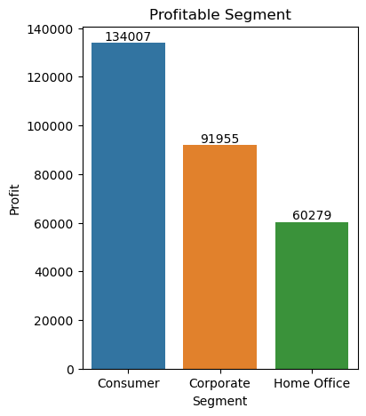

```python
plt.figure(figsize=(4,5))
df1=pd.DataFrame(df.groupby(['Segment'])['Profit'].sum()).sort_values(by='Profit',ascending=False)
ax=sns.barplot(x=df1.index,y=df1.Profit)
for bars in ax.containers:
    ax.bar_label(bars)
plt.title("Profitable Segment")
```

BY

HEMA PRABHAVATHI